# BoneMarrowMap on held-out cells, compared with SingleR and scANVI

JN Taroni

2026

## Introduction

This notebook compares three annotations of the held-out study’s cells (`params$holdout_study`, mumme_2023 by default) with each other and with the atlas labels:

- **SingleR** and **scANVI**: references trained on the AML scAtlas without this study (`04_predict-holdout-singler.R`, `04_predict-holdout-scanvi.py`; evaluated in `05_evaluate-holdout.Rmd`).
- **BoneMarrowMap**: Symphony mapping onto a reference built only from healthy bone marrow, then kNN cell type and pseudotime prediction (`04_predict-holdout-bonemarrowmap.R`).

The question is whether BoneMarrowMap is a useful third opinion for ScPCA SCPCP000007, especially for HSPC/blast states. See `.workspace/annotate-aml/bonemarrowmap.md` for the plan and decisions.

Things to keep in mind while reading:

- **BoneMarrowMap has its own labels** (55 fine, 24 broad), and they don’t match the atlas’s. There’s no crosswalk, so this notebook has no BoneMarrowMap accuracy. It compares labelings directly: cross-tabs, and agreement measures that don’t need shared labels.
- **The reference is normal-only.** Blasts get mapped onto normal states, so a `-like`/`LSC` cell landing on “HSC” or “GMP” isn’t necessarily an error.
- **Mapping QC is relative to the query.** A cell fails if its mapping error is more than 2.5 MADs above the median of *this study’s* cells. So about the same fraction fails in any query. The failure rate isn’t an absolute measure of mapping quality, and in AML the median itself rises with off-reference blasts.
- **Every comparison uses the same cells for all three methods**, once for all cells and once for cells that pass BoneMarrowMap’s QC. Dropping QC failures for BoneMarrowMap alone would favor it.
- **Gene coverage.** Only 2,133 of BoneMarrowMap’s 2,386 mapping genes (89.4%) are in the atlas. About 40–60 are renamed genes, mostly histones. The rest aren’t in the atlas at all, including HLA class I/II, `B2M`, `PTPRC`, `MALAT1`, `ELANE`, `PRTN3`, `AZU1`, `MS4A3`, `LILRA4` and `IRF7`. Missing genes are set to the reference mean, so they carry no signal. SingleR and scANVI never had these genes either. On SCPCP000007, BoneMarrowMap will have them, so this study probably makes BoneMarrowMap look worse than it will on ScPCA.
- mumme_2023 has the atlas’s only 5′ data, and every result is split by assay. Each sample is one donor on one assay.
- “Truth” is the atlas annotation, which is itself a prediction from the atlas authors.

## Setup

```r
suppressPackageStartupMessages({
  library(dplyr)
  library(ggplot2)
})

holdout_study <- params$holdout_study

root_dir <- rprojroot::find_root(rprojroot::has_dir(".git"))
module_dir <- fs::path(root_dir, "analyses", "annotate-aml")
atlas_file <- fs::path(root_dir, "data", "AML-scAtlas", "AML_scAtlas_le29.h5ad")
holdout_dir <- fs::path(module_dir, "results", "holdout")
singler_file <- fs::path(holdout_dir, paste0("singler_predictions_", holdout_study, ".tsv"))
scanvi_file <- fs::path(holdout_dir, paste0("scanvi_predictions_", holdout_study, ".tsv"))
bmm_file <- fs::path(holdout_dir, paste0("bonemarrowmap_predictions_", holdout_study, ".tsv"))

stopifnot(
  fs::file_exists(atlas_file),
  fs::file_exists(singler_file),
  fs::file_exists(scanvi_file),
  fs::file_exists(bmm_file)
)

# Plot style, metric and plotting functions shared with 05_evaluate-holdout.Rmd
source(fs::path(module_dir, "utils", "eval-helpers.R"))

# BoneMarrowMap's mapping-QC threshold, in MADs above the query median (package default)
mad_threshold <- 2.5
```

Plot styling: color identifies the **method** (categorical slots 1–3 of the reference palette), and assays are separate panels. Heatmaps use a single blue ramp.

```r
method_colors <- method_colors_all[c("SingleR", "scANVI", "BoneMarrowMap")]
theme_set(eval_theme())
scale_color_method <- scale_color_manual(values = method_colors, name = "Method")
```

## Load truth and predictions

True labels, assay and donor for the held-out cells, from the atlas subset (metadata only).

```r
adata <- anndataR::read_h5ad(atlas_file, as = "HDF5AnnData")
obs <- adata$obs
obs$cell_id <- adata$obs_names
rm(adata)

# label_fine -> label_broad map; each fine class belongs to exactly one broad class
label_map <- obs |>
  distinct(label_fine = as.character(label_fine), label_broad = as.character(label_broad))
stopifnot(!anyDuplicated(label_map$label_fine))

truth <- obs |>
  filter(Study == holdout_study) |>
  transmute(
    cell_id,
    donor_id = as.character(donor_id),
    assay = as.character(assay),
    true_fine = as.character(label_fine),
    true_broad = as.character(label_broad)
  )

nrow(truth)
```

```
[1] 46588
```

One row per cell, with all three methods’ labels and confidence measures. SingleR labels are **unpruned**, as in 05. BoneMarrowMap labels are kept for every cell, including QC failures (`bmm_pass` marks the cells that pass).

```r
singler <- data.table::fread(singler_file, data.table = FALSE)
scanvi <- data.table::fread(scanvi_file, data.table = FALSE)
bmm <- data.table::fread(bmm_file, data.table = FALSE)

stopifnot(
  setequal(singler$cell_id, truth$cell_id),
  setequal(scanvi$cell_id, truth$cell_id),
  setequal(bmm$cell_id, truth$cell_id)
)

is_malignant_like <- function(label) grepl("-like$", label) | label == "HSPC:LSC"

cells <- truth |>
  inner_join(
    singler |> transmute(cell_id, singler_fine = singler_label, singler_delta_next),
    by = "cell_id"
  ) |>
  inner_join(
    scanvi |> transmute(cell_id, scanvi_fine = scanvi_label, scanvi_max_prob),
    by = "cell_id"
  ) |>
  inner_join(
    bmm |> transmute(
      cell_id, bmm_assay = assay, bmm_label, bmm_label_broad, bmm_label_prob,
      bmm_pseudotime, bmm_mapping_error, bmm_mapping_qc
    ),
    by = "cell_id"
  ) |>
  left_join(
    label_map |> rename(singler_fine = label_fine, singler_broad = label_broad),
    by = "singler_fine"
  ) |>
  left_join(
    label_map |> rename(scanvi_fine = label_fine, scanvi_broad = label_broad),
    by = "scanvi_fine"
  ) |>
  mutate(
    bmm_pass = bmm_mapping_qc == "Pass",
    true_mal = is_malignant_like(true_fine)
  )

stopifnot(
  nrow(cells) == nrow(truth),
  identical(cells$assay, cells$bmm_assay),
  !anyNA(cells$singler_broad),
  !anyNA(cells$scanvi_broad),
  !anyNA(cells$bmm_label),
  !anyNA(cells$bmm_mapping_error)
)

count(cells, assay)
```

| assay | n |
| --- | --- |
| 10x 3' v3 | 16119 |
| 10x 5' v1 | 30469 |

### Pseudotime outside the hierarchy

BoneMarrowMap’s pseudotime covers the lineages that come from HSCs in its reference (myeloid, erythroid, B and DC). T, NK, plasma and stromal cells sit outside it and get a placeholder 0. That’s the same value as the most primitive stem cells, but it means “undefined”, not “early”. So for cells with those labels, this notebook sets pseudotime to `NA`. Otherwise a blast that lands among T cells would look maximally primitive. The labels themselves are kept.

The check below shows the distinction: cells with off-hierarchy labels are almost all exactly 0, while cells with hierarchy labels, even HSCs, rarely are.

```r
off_hierarchy_broad <- c("Naive T", "CD4 Memory T", "CD8 Memory T", "NK", "Plasma Cell", "Stromal")
stopifnot(all(off_hierarchy_broad %in% cells$bmm_label_broad))

cells <- cells |>
  mutate(
    bmm_off_hierarchy = bmm_label_broad %in% off_hierarchy_broad,
    bmm_pseudotime_raw = bmm_pseudotime,
    bmm_pseudotime = if_else(bmm_off_hierarchy, NA_real_, bmm_pseudotime)
  )

cells |>
  group_by(bmm_off_hierarchy) |>
  summarize(
    n_cells = n(),
    frac_exactly_0 = mean(bmm_pseudotime_raw == 0),
    median_raw = median(bmm_pseudotime_raw)
  ) |>
  knitr::kable(digits = 3)
```

| bmm_off_hierarchy | n_cells | frac_exactly_0 | median_raw |
| --- | --- | --- | --- |
| FALSE | 39855 | 0.006 | 14.449 |
| TRUE | 6733 | 1.000 | 0.000 |

BoneMarrowMap’s labels, in an order used throughout. Labels in the hierarchy come first, by the median pseudotime of the query cells given that label, so they run roughly from stem cells to mature cells. The off-hierarchy labels follow in a fixed order (T, NK, plasma, stromal).

```r
order_bmm_labels <- function(cells, label_col) {
  medians <- cells |>
    filter(!bmm_off_hierarchy) |>
    group_by(label = .data[[label_col]]) |>
    summarize(median_pt = median(bmm_pseudotime)) |>
    arrange(median_pt, label) |>
    pull(label)
  off <- cells |>
    filter(bmm_off_hierarchy) |>
    mutate(group = match(bmm_label_broad, off_hierarchy_broad)) |>
    distinct(label = .data[[label_col]], group) |>
    arrange(group, label) |>
    pull(label)
  c(medians, off)
}

bmm_fine_levels <- order_bmm_labels(cells, "bmm_label")
bmm_broad_levels <- order_bmm_labels(cells, "bmm_label_broad")
stopifnot(
  setequal(bmm_fine_levels, unique(cells$bmm_label)),
  setequal(bmm_broad_levels, unique(cells$bmm_label_broad))
)

# Order the rows of a cross-tab so the heatmap is as close to diagonal as possible: by the
# share-weighted mean position of each row label's cells along the columns
diagonal_row_order <- function(df, col_levels) {
  df |>
    count(row, col) |>
    group_by(row) |>
    summarize(position = sum(n * match(col, col_levels)) / sum(n)) |>
    arrange(position) |>
    pull(row)
}
```

## Mapping QC

How many cells fail BoneMarrowMap’s mapping QC? First, a check that the TSV’s QC flag matches the threshold recomputed from the mapping-error scores. The rest of the notebook relies on this to try other thresholds.

```r
qc_threshold <- function(error, n_mads) median(error) + n_mads * mad(error)

recomputed_threshold <- qc_threshold(cells$bmm_mapping_error, mad_threshold)
recomputed_pass <- cells$bmm_mapping_error < recomputed_threshold
# The TSV stores scores as text, so allow mismatches only for cells right at the threshold
mismatch <- recomputed_pass != cells$bmm_pass
stopifnot(
  "Recomputed QC flags don't match the TSV" =
    all(abs(cells$bmm_mapping_error[mismatch] - recomputed_threshold) < 1e-6)
)
sum(mismatch)
```

```
[1] 0
```

```r
cells |>
  group_by(assay) |>
  summarize(n_cells = n(), n_fail = sum(!bmm_pass), frac_fail = mean(!bmm_pass)) |>
  knitr::kable(digits = 3)
```

| assay | n_cells | n_fail | frac_fail |
| --- | --- | --- | --- |
| 10x 3’ v3 | 16119 | 829 | 0.051 |
| 10x 5’ v1 | 30469 | 1108 | 0.036 |

Mapping-error distributions by donor. The dashed line is the 2.5-MAD threshold computed over all cells. Donor and assay are confounded (each donor is on one assay), so a per-donor threshold would also hide any difference between assays.

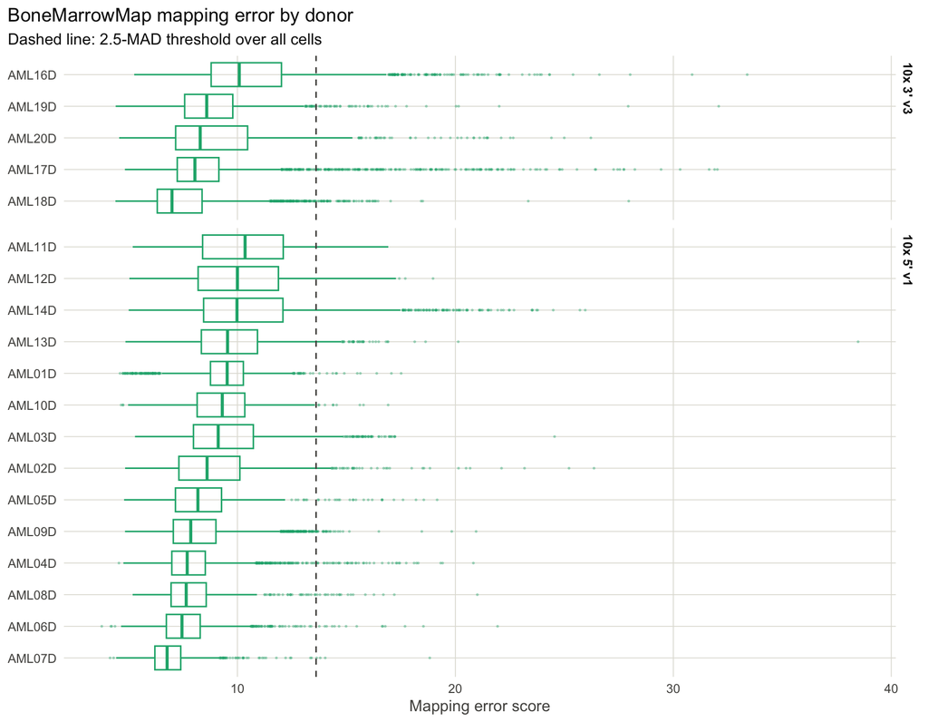

```r
global_threshold <- recomputed_threshold

donor_order <- cells |>
  group_by(donor_id) |>
  summarize(median_error = median(bmm_mapping_error)) |>
  arrange(median_error) |>
  pull(donor_id)

cells |>
  mutate(donor_id = factor(donor_id, levels = donor_order)) |>
  ggplot(aes(x = bmm_mapping_error, y = donor_id)) +
  geom_boxplot(
    color = method_colors[["BoneMarrowMap"]], fill = NA, outlier.size = 0.3,
    outlier.alpha = 0.3
  ) +
  geom_vline(xintercept = global_threshold, linetype = "dashed", color = ink_secondary) +
  facet_grid(assay ~ ., scales = "free_y", space = "free_y") +
  labs(
    x = "Mapping error score", y = NULL,
    title = "BoneMarrowMap mapping error by donor",
    subtitle = paste0("Dashed line: ", mad_threshold, "-MAD threshold over all cells")
  )
```

Which true labels fail most often? Labels with fewer than 50 cells in an assay are left out.

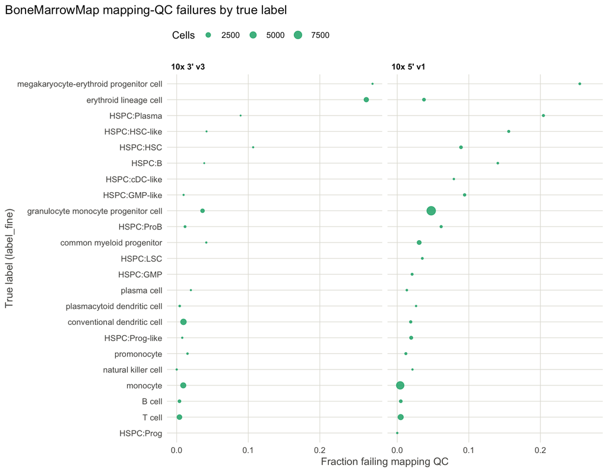

```r
qc_by_truth <- cells |>
  group_by(assay, true_fine) |>
  summarize(n_cells = n(), frac_fail = mean(!bmm_pass), .groups = "drop") |>
  filter(n_cells >= 50)

qc_truth_order <- qc_by_truth |>
  group_by(true_fine) |>
  summarize(mean_fail = mean(frac_fail)) |>
  arrange(mean_fail) |>
  pull(true_fine)

qc_by_truth |>
  mutate(true_fine = factor(true_fine, levels = qc_truth_order)) |>
  ggplot(aes(x = frac_fail, y = true_fine, size = n_cells)) +
  geom_point(color = method_colors[["BoneMarrowMap"]], alpha = 0.85) +
  facet_wrap(~assay) +
  scale_size_area(max_size = 4, name = "Cells") +
  labs(x = "Fraction failing mapping QC", y = "True label (label_fine)",
       title = "BoneMarrowMap mapping-QC failures by true label")
```

Malignant-proxy (`-like`/`LSC`) cells compared with other cells, and with other HSPCs only (true `label_broad` = `hematopoietic stem cell`), since HSPCs may map differently anyway.

```r
cells |>
  mutate(
    group = case_when(
      true_mal ~ "-like/LSC",
      true_broad == "hematopoietic stem cell" ~ "other HSPC",
      TRUE ~ "non-HSPC"
    )
  ) |>
  group_by(assay, group) |>
  summarize(
    n_cells = n(),
    frac_fail = mean(!bmm_pass),
    median_error = median(bmm_mapping_error),
    .groups = "drop"
  ) |>
  knitr::kable(digits = 3)
```

| assay | group | n_cells | frac_fail | median_error |
| --- | --- | --- | --- | --- |
| 10x 3’ v3 | -like/LSC | 373 | 0.029 | 9.826 |
| 10x 3’ v3 | non-HSPC | 15094 | 0.051 | 8.362 |
| 10x 3’ v3 | other HSPC | 652 | 0.069 | 9.333 |
| 10x 5’ v1 | -like/LSC | 2505 | 0.067 | 10.589 |
| 10x 5’ v1 | non-HSPC | 25408 | 0.027 | 8.226 |
| 10x 5’ v1 | other HSPC | 2556 | 0.095 | 10.254 |

## Native-label cross-tabs

The main view of how the label sets relate. Rows are normalized to sum to 1 within each assay, so a row shows where that label’s cells went in BoneMarrowMap. Columns are BoneMarrowMap labels in pseudotime order. All cells, including QC failures.

### Truth vs. BoneMarrowMap

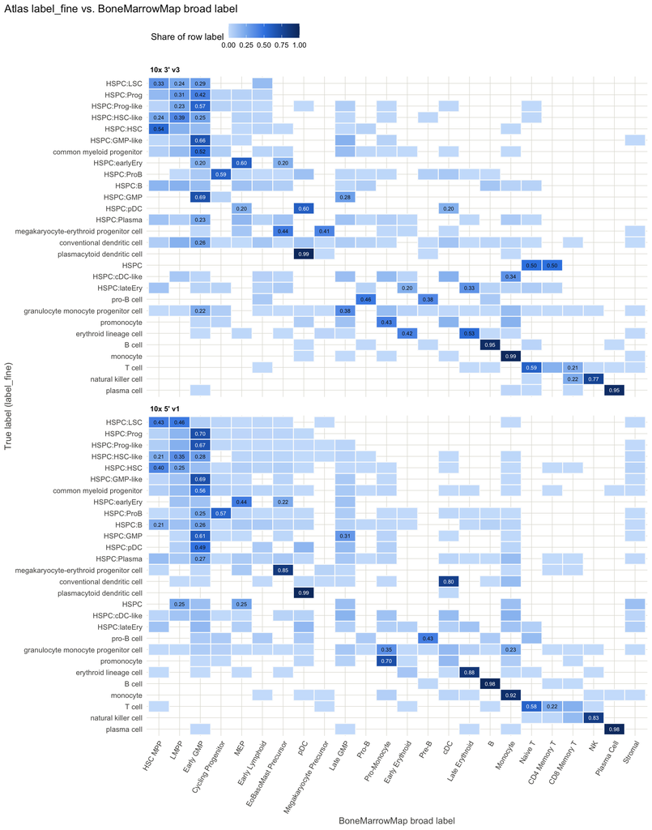

```r
truth_vs_bmm_broad <- cells |> transmute(assay, row = true_fine, col = bmm_label_broad)

plot_crosstab(
  truth_vs_bmm_broad,
  title = "Atlas label_fine vs. BoneMarrowMap broad label",
  row_title = "True label (label_fine)",
  col_title = "BoneMarrowMap broad label",
  row_levels = diagonal_row_order(truth_vs_bmm_broad, bmm_broad_levels),
  col_levels = bmm_broad_levels
)
```

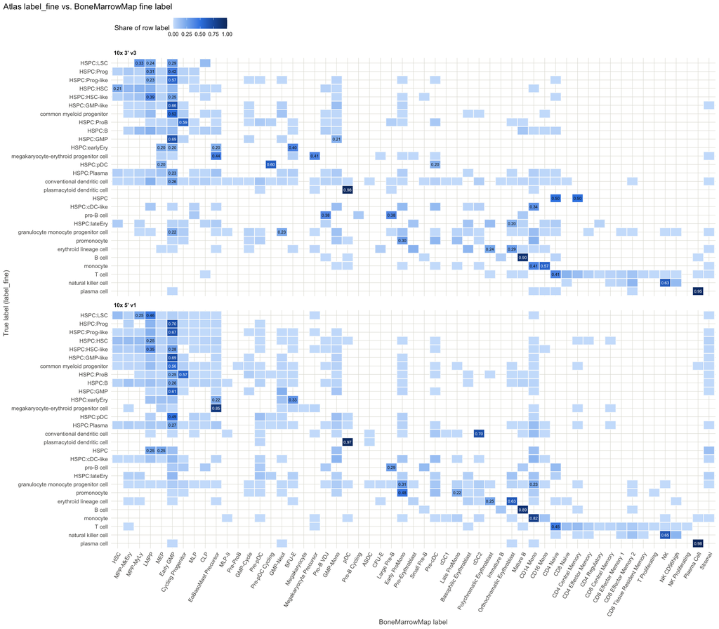

```r
truth_vs_bmm_fine <- cells |> transmute(assay, row = true_fine, col = bmm_label)

plot_crosstab(
  truth_vs_bmm_fine,
  title = "Atlas label_fine vs. BoneMarrowMap fine label",
  row_title = "True label (label_fine)",
  col_title = "BoneMarrowMap label",
  row_levels = diagonal_row_order(truth_vs_bmm_fine, bmm_fine_levels),
  col_levels = bmm_fine_levels
)
```

The same in the other direction: what each BoneMarrowMap broad label is made of in the atlas labels. Rows are BoneMarrowMap labels.

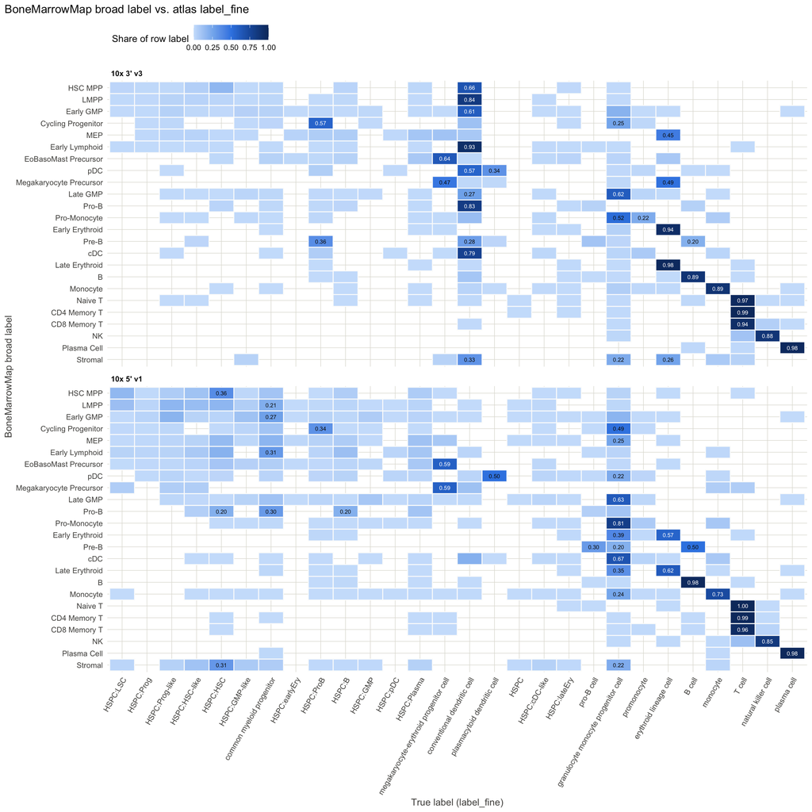

```r
bmm_vs_truth <- cells |> transmute(assay, row = bmm_label_broad, col = true_fine)
truth_levels <- diagonal_row_order(truth_vs_bmm_broad, bmm_broad_levels)

plot_crosstab(
  bmm_vs_truth,
  title = "BoneMarrowMap broad label vs. atlas label_fine",
  row_title = "BoneMarrowMap broad label",
  col_title = "True label (label_fine)",
  row_levels = bmm_broad_levels,
  col_levels = truth_levels
)
```

The atlas-label × BoneMarrowMap cross-tab again, for cells passing QC only, to see whether the failures change the picture.

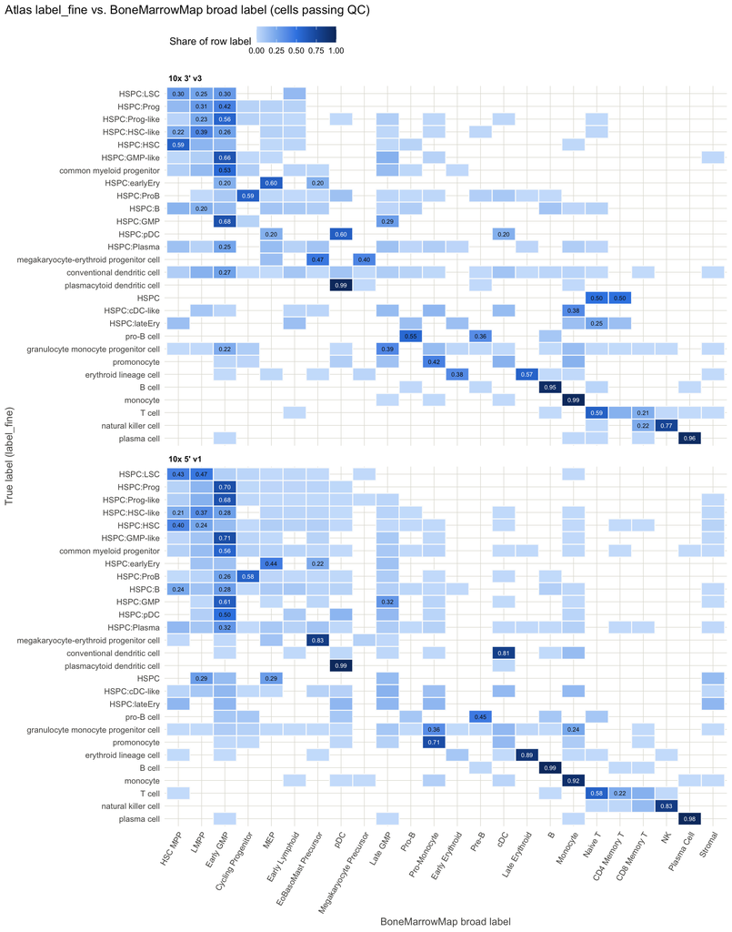

```r
truth_vs_bmm_broad_pass <- cells |>
  filter(bmm_pass) |>
  transmute(assay, row = true_fine, col = bmm_label_broad)

plot_crosstab(
  truth_vs_bmm_broad_pass,
  title = "Atlas label_fine vs. BoneMarrowMap broad label (cells passing QC)",
  row_title = "True label (label_fine)",
  col_title = "BoneMarrowMap broad label",
  row_levels = truth_levels,
  col_levels = bmm_broad_levels
)
```

### SingleR and scANVI vs. BoneMarrowMap

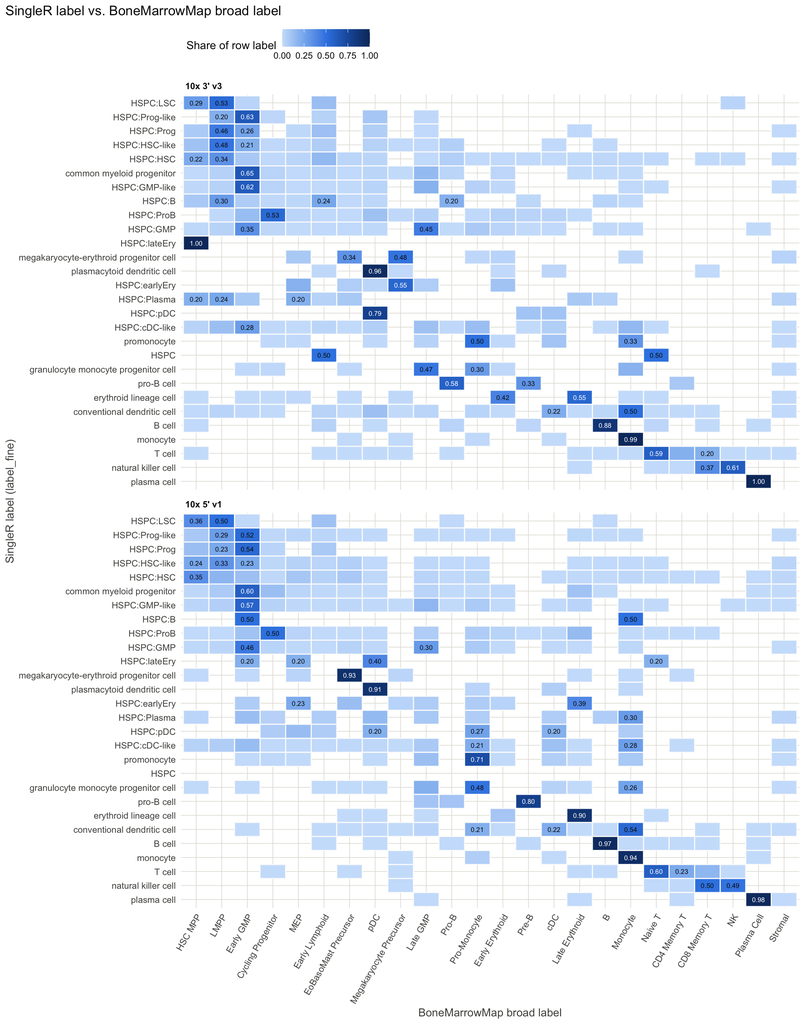

```r
singler_vs_bmm <- cells |> transmute(assay, row = singler_fine, col = bmm_label_broad)

plot_crosstab(
  singler_vs_bmm,
  title = "SingleR label vs. BoneMarrowMap broad label",
  row_title = "SingleR label (label_fine)",
  col_title = "BoneMarrowMap broad label",
  row_levels = diagonal_row_order(singler_vs_bmm, bmm_broad_levels),
  col_levels = bmm_broad_levels
)
```

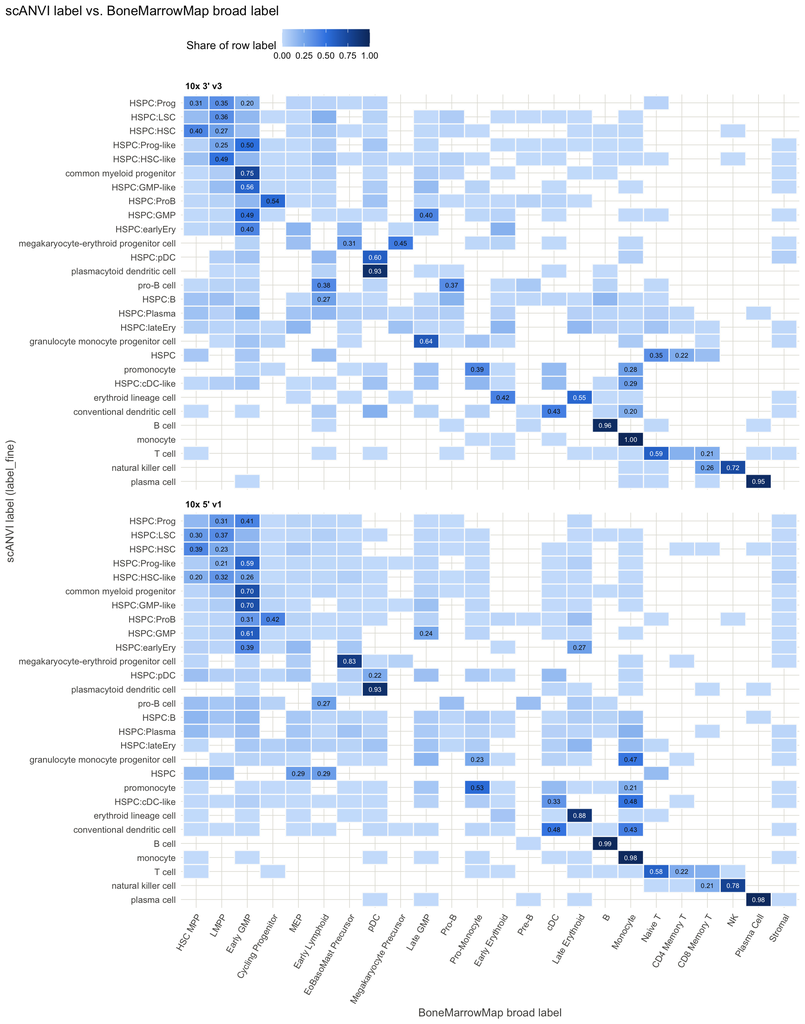

```r
scanvi_vs_bmm <- cells |> transmute(assay, row = scanvi_fine, col = bmm_label_broad)

plot_crosstab(
  scanvi_vs_bmm,
  title = "scANVI label vs. BoneMarrowMap broad label",
  row_title = "scANVI label (label_fine)",
  col_title = "BoneMarrowMap broad label",
  row_levels = diagonal_row_order(scanvi_vs_bmm, bmm_broad_levels),
  col_levels = bmm_broad_levels
)
```

## Agreement without shared labels

Two measures of how similarly two labelings group the same cells, whatever the labels are called:

- **Adjusted Rand index (ARI):** 1 = the same grouping, about 0 = no better than chance.
- **Normalized mutual information (NMI):** 1 = the same grouping, 0 = independent.

Both are lowered by differences in granularity alone. BoneMarrowMap has 10 T cell labels and the atlas has one, so a perfectly consistent method still scores below 1. Read them as comparisons between methods, not as absolute measures. SingleR and scANVI are at `label_fine`, the level they were trained on.

```r
labelings <- c(
  "Truth (fine)" = "true_fine",
  "Truth (broad)" = "true_broad",
  "SingleR" = "singler_fine",
  "scANVI" = "scanvi_fine",
  "BoneMarrowMap (fine)" = "bmm_label",
  "BoneMarrowMap (broad)" = "bmm_label_broad"
)
labeling_pairs <- combn(names(labelings), 2, simplify = FALSE)

agreement_scores <- function(df) {
  purrr::map(labeling_pairs, \(pair) {
    x <- df[[labelings[[pair[1]]]]]
    y <- df[[labelings[[pair[2]]]]]
    tibble::tibble(
      labeling_1 = pair[1],
      labeling_2 = pair[2],
      ari = adjusted_rand_index(x, y),
      nmi = normalized_mutual_info(x, y)
    )
  }) |>
    purrr::list_rbind()
}

agreement <- bind_rows(
  cells |> mutate(cell_subset = "All cells"),
  cells |> filter(bmm_pass) |> mutate(cell_subset = "Passing BoneMarrowMap QC")
) |>
  group_by(cell_subset, assay) |>
  group_modify(\(df, key) agreement_scores(df)) |>
  ungroup()
```

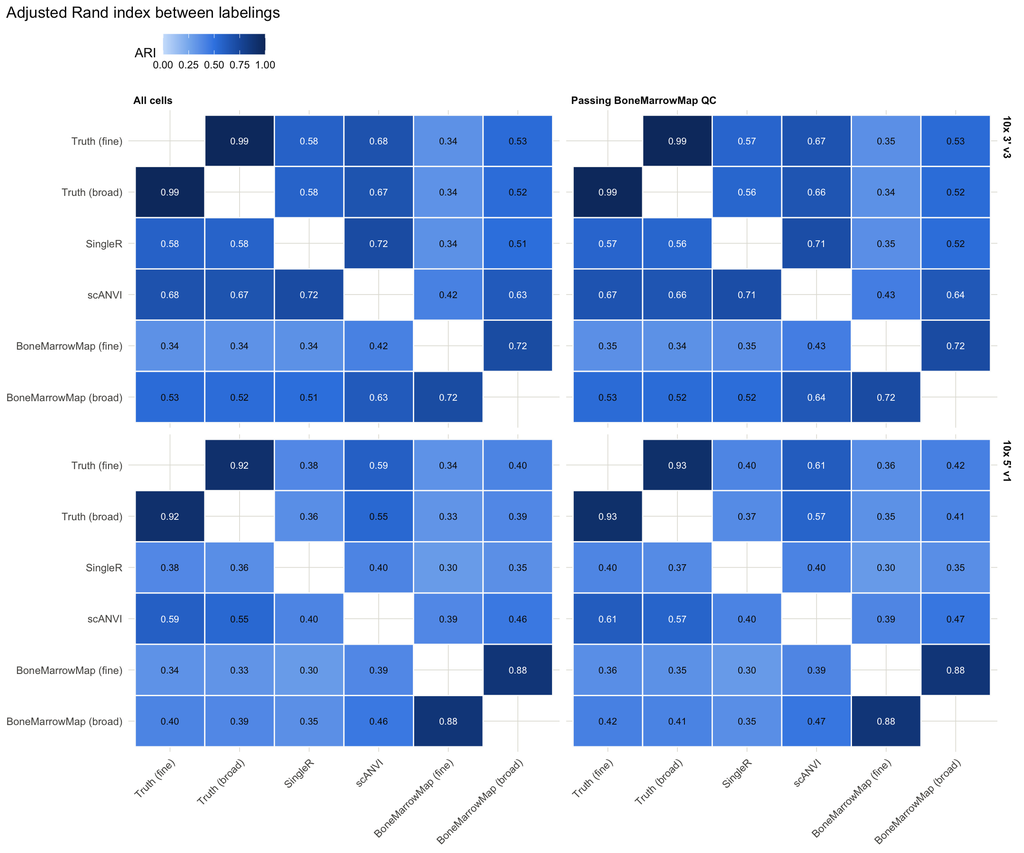

```r
plot_agreement <- function(agreement, measure, title) {
  # both triangles, so each labeling's row reads across
  both <- bind_rows(
    agreement |> transmute(cell_subset, assay, x = labeling_1, y = labeling_2, value = .data[[measure]]),
    agreement |> transmute(cell_subset, assay, x = labeling_2, y = labeling_1, value = .data[[measure]])
  ) |>
    mutate(
      x = factor(x, levels = names(labelings)),
      y = factor(y, levels = rev(names(labelings)))
    )
  ggplot(both, aes(x = x, y = y, fill = value)) +
    geom_tile(color = "#fcfcfb", linewidth = 0.5) +
    geom_text(aes(label = sprintf("%.2f", value), color = value > 0.55), size = 2.8,
              show.legend = FALSE) +
    scale_fill_gradientn(colors = seq_blue, limits = c(0, 1), name = toupper(measure)) +
    scale_color_manual(values = c(`FALSE` = ink_primary, `TRUE` = "#ffffff")) +
    facet_grid(assay ~ cell_subset) +
    labs(x = NULL, y = NULL, title = title) +
    theme(axis.text.x = element_text(angle = 45, hjust = 1), panel.grid = element_blank())
}

plot_agreement(agreement, "ari", "Adjusted Rand index between labelings")
```

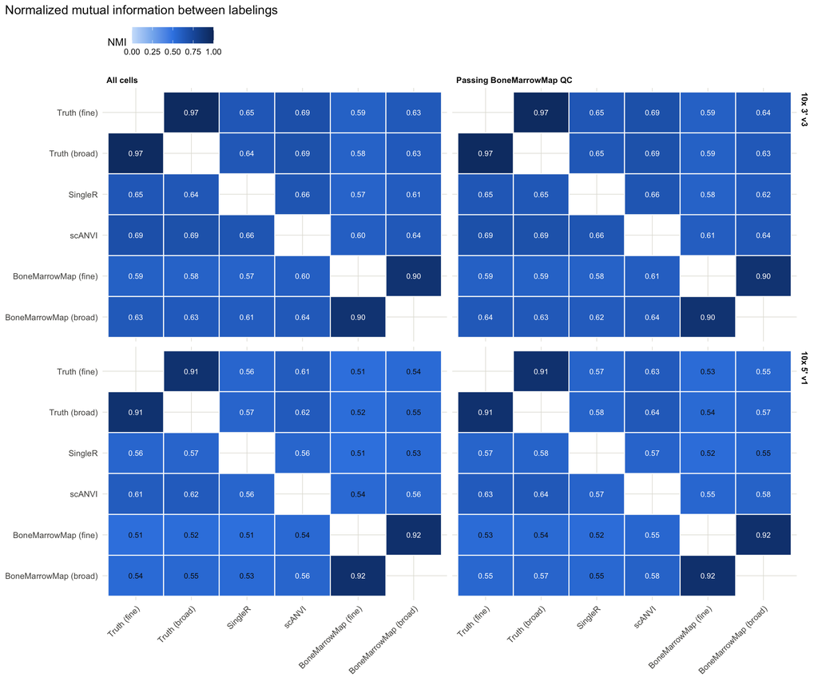

```r
plot_agreement(agreement, "nmi", "Normalized mutual information between labelings")
```

```r
agreement |>
  arrange(cell_subset, assay, labeling_1, labeling_2) |>
  knitr::kable(digits = 3)
```

| cell_subset | assay | labeling_1 | labeling_2 | ari | nmi |
| --- | --- | --- | --- | --- | --- |
| All cells | 10x 3’ v3 | BoneMarrowMap (fine) | BoneMarrowMap (broad) | 0.717 | 0.901 |
| All cells | 10x 3’ v3 | SingleR | BoneMarrowMap (broad) | 0.514 | 0.612 |
| All cells | 10x 3’ v3 | SingleR | BoneMarrowMap (fine) | 0.345 | 0.575 |
| All cells | 10x 3’ v3 | SingleR | scANVI | 0.718 | 0.656 |
| All cells | 10x 3’ v3 | Truth (broad) | BoneMarrowMap (broad) | 0.520 | 0.629 |
| All cells | 10x 3’ v3 | Truth (broad) | BoneMarrowMap (fine) | 0.338 | 0.582 |
| All cells | 10x 3’ v3 | Truth (broad) | SingleR | 0.575 | 0.643 |
| All cells | 10x 3’ v3 | Truth (broad) | scANVI | 0.669 | 0.687 |
| All cells | 10x 3’ v3 | Truth (fine) | BoneMarrowMap (broad) | 0.527 | 0.633 |
| All cells | 10x 3’ v3 | Truth (fine) | BoneMarrowMap (fine) | 0.342 | 0.587 |
| All cells | 10x 3’ v3 | Truth (fine) | SingleR | 0.583 | 0.647 |
| All cells | 10x 3’ v3 | Truth (fine) | Truth (broad) | 0.987 | 0.967 |
| All cells | 10x 3’ v3 | Truth (fine) | scANVI | 0.679 | 0.693 |
| All cells | 10x 3’ v3 | scANVI | BoneMarrowMap (broad) | 0.627 | 0.636 |
| All cells | 10x 3’ v3 | scANVI | BoneMarrowMap (fine) | 0.419 | 0.601 |
| All cells | 10x 5’ v1 | BoneMarrowMap (fine) | BoneMarrowMap (broad) | 0.877 | 0.920 |
| All cells | 10x 5’ v1 | SingleR | BoneMarrowMap (broad) | 0.348 | 0.532 |
| All cells | 10x 5’ v1 | SingleR | BoneMarrowMap (fine) | 0.298 | 0.508 |
| All cells | 10x 5’ v1 | SingleR | scANVI | 0.401 | 0.563 |
| All cells | 10x 5’ v1 | Truth (broad) | BoneMarrowMap (broad) | 0.388 | 0.547 |
| All cells | 10x 5’ v1 | Truth (broad) | BoneMarrowMap (fine) | 0.327 | 0.518 |
| All cells | 10x 5’ v1 | Truth (broad) | SingleR | 0.356 | 0.566 |
| All cells | 10x 5’ v1 | Truth (broad) | scANVI | 0.547 | 0.624 |
| All cells | 10x 5’ v1 | Truth (fine) | BoneMarrowMap (broad) | 0.403 | 0.536 |
| All cells | 10x 5’ v1 | Truth (fine) | BoneMarrowMap (fine) | 0.338 | 0.513 |
| All cells | 10x 5’ v1 | Truth (fine) | SingleR | 0.384 | 0.561 |
| All cells | 10x 5’ v1 | Truth (fine) | Truth (broad) | 0.920 | 0.907 |
| All cells | 10x 5’ v1 | Truth (fine) | scANVI | 0.594 | 0.614 |
| All cells | 10x 5’ v1 | scANVI | BoneMarrowMap (broad) | 0.464 | 0.563 |
| All cells | 10x 5’ v1 | scANVI | BoneMarrowMap (fine) | 0.386 | 0.540 |
| Passing BoneMarrowMap QC | 10x 3’ v3 | BoneMarrowMap (fine) | BoneMarrowMap (broad) | 0.721 | 0.902 |
| Passing BoneMarrowMap QC | 10x 3’ v3 | SingleR | BoneMarrowMap (broad) | 0.518 | 0.618 |
| Passing BoneMarrowMap QC | 10x 3’ v3 | SingleR | BoneMarrowMap (fine) | 0.353 | 0.582 |
| Passing BoneMarrowMap QC | 10x 3’ v3 | SingleR | scANVI | 0.707 | 0.658 |
| Passing BoneMarrowMap QC | 10x 3’ v3 | Truth (broad) | BoneMarrowMap (broad) | 0.524 | 0.635 |
| Passing BoneMarrowMap QC | 10x 3’ v3 | Truth (broad) | BoneMarrowMap (fine) | 0.343 | 0.587 |
| Passing BoneMarrowMap QC | 10x 3’ v3 | Truth (broad) | SingleR | 0.558 | 0.645 |
| Passing BoneMarrowMap QC | 10x 3’ v3 | Truth (broad) | scANVI | 0.657 | 0.687 |
| Passing BoneMarrowMap QC | 10x 3’ v3 | Truth (fine) | BoneMarrowMap (broad) | 0.530 | 0.638 |
| Passing BoneMarrowMap QC | 10x 3’ v3 | Truth (fine) | BoneMarrowMap (fine) | 0.347 | 0.592 |
| Passing BoneMarrowMap QC | 10x 3’ v3 | Truth (fine) | SingleR | 0.565 | 0.648 |
| Passing BoneMarrowMap QC | 10x 3’ v3 | Truth (fine) | Truth (broad) | 0.988 | 0.968 |
| Passing BoneMarrowMap QC | 10x 3’ v3 | Truth (fine) | scANVI | 0.666 | 0.692 |
| Passing BoneMarrowMap QC | 10x 3’ v3 | scANVI | BoneMarrowMap (broad) | 0.639 | 0.643 |
| Passing BoneMarrowMap QC | 10x 3’ v3 | scANVI | BoneMarrowMap (fine) | 0.432 | 0.608 |
| Passing BoneMarrowMap QC | 10x 5’ v1 | BoneMarrowMap (fine) | BoneMarrowMap (broad) | 0.877 | 0.919 |
| Passing BoneMarrowMap QC | 10x 5’ v1 | SingleR | BoneMarrowMap (broad) | 0.354 | 0.547 |
| Passing BoneMarrowMap QC | 10x 5’ v1 | SingleR | BoneMarrowMap (fine) | 0.302 | 0.521 |
| Passing BoneMarrowMap QC | 10x 5’ v1 | SingleR | scANVI | 0.405 | 0.571 |
| Passing BoneMarrowMap QC | 10x 5’ v1 | Truth (broad) | BoneMarrowMap (broad) | 0.409 | 0.566 |
| Passing BoneMarrowMap QC | 10x 5’ v1 | Truth (broad) | BoneMarrowMap (fine) | 0.346 | 0.536 |
| Passing BoneMarrowMap QC | 10x 5’ v1 | Truth (broad) | SingleR | 0.371 | 0.576 |
| Passing BoneMarrowMap QC | 10x 5’ v1 | Truth (broad) | scANVI | 0.571 | 0.637 |
| Passing BoneMarrowMap QC | 10x 5’ v1 | Truth (fine) | BoneMarrowMap (broad) | 0.422 | 0.554 |
| Passing BoneMarrowMap QC | 10x 5’ v1 | Truth (fine) | BoneMarrowMap (fine) | 0.355 | 0.529 |
| Passing BoneMarrowMap QC | 10x 5’ v1 | Truth (fine) | SingleR | 0.397 | 0.570 |
| Passing BoneMarrowMap QC | 10x 5’ v1 | Truth (fine) | Truth (broad) | 0.928 | 0.911 |
| Passing BoneMarrowMap QC | 10x 5’ v1 | Truth (fine) | scANVI | 0.614 | 0.625 |
| Passing BoneMarrowMap QC | 10x 5’ v1 | scANVI | BoneMarrowMap (broad) | 0.473 | 0.581 |
| Passing BoneMarrowMap QC | 10x 5’ v1 | scANVI | BoneMarrowMap (fine) | 0.394 | 0.555 |

### Sensitivity to the QC threshold

At thresholds of 2, 2.5 (the default), 3 and 4 MADs, plus no QC filtering, which fraction of cells is kept, and how well does each method agree with the atlas `label_fine` on those cells? All three methods are scored on the same kept cells.

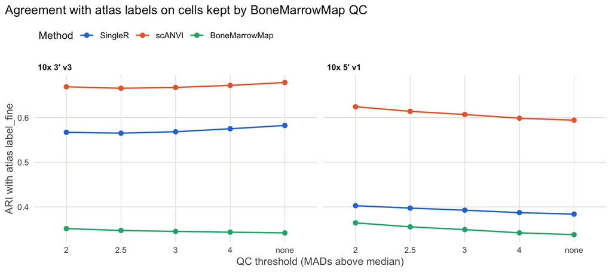

```r
qc_settings <- c("2", "2.5", "3", "4", "none")

sensitivity <- purrr::map(qc_settings, \(setting) {
  kept <- if (setting == "none") {
    rep(TRUE, nrow(cells))
  } else {
    cells$bmm_mapping_error < qc_threshold(cells$bmm_mapping_error, as.numeric(setting))
  }
  cells[kept, ] |>
    group_by(assay) |>
    summarize(
      qc_mads = setting,
      n_kept = n(),
      ari_SingleR = adjusted_rand_index(true_fine, singler_fine),
      ari_scANVI = adjusted_rand_index(true_fine, scanvi_fine),
      ari_BoneMarrowMap = adjusted_rand_index(true_fine, bmm_label),
      .groups = "drop"
    )
}) |>
  purrr::list_rbind() |>
  left_join(count(cells, assay, name = "n_total"), by = "assay") |>
  mutate(frac_kept = n_kept / n_total, qc_mads = factor(qc_mads, levels = qc_settings))

sensitivity_long <- sensitivity |>
  tidyr::pivot_longer(starts_with("ari_"), names_to = "method", names_prefix = "ari_",
                      values_to = "ari") |>
  mutate(method = factor(method, levels = names(method_colors)))

ggplot(sensitivity_long, aes(x = qc_mads, y = ari, color = method, group = method)) +
  geom_line(linewidth = 0.7) +
  geom_point(size = 2) +
  facet_wrap(~assay) +
  scale_color_method +
  labs(x = "QC threshold (MADs above median)", y = "ARI with atlas label_fine",
       title = "Agreement with atlas labels on cells kept by BoneMarrowMap QC")
```

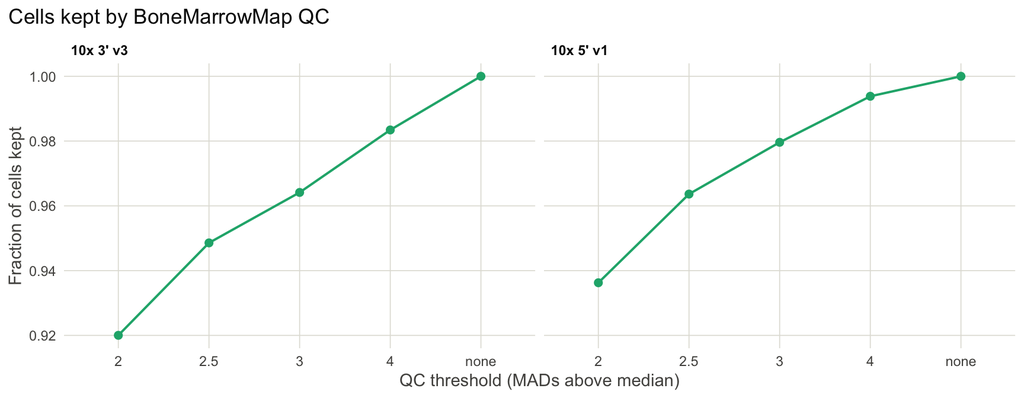

```r
ggplot(sensitivity, aes(x = qc_mads, y = frac_kept, group = 1)) +
  geom_line(color = method_colors[["BoneMarrowMap"]], linewidth = 0.7) +
  geom_point(color = method_colors[["BoneMarrowMap"]], size = 2) +
  facet_wrap(~assay) +
  scale_y_continuous(limits = c(NA, 1)) +
  labs(x = "QC threshold (MADs above median)", y = "Fraction of cells kept",
       title = "Cells kept by BoneMarrowMap QC")
```

```r
sensitivity |>
  select(assay, qc_mads, n_kept, frac_kept, starts_with("ari_")) |>
  arrange(assay, qc_mads) |>
  knitr::kable(digits = 3)
```

| assay | qc_mads | n_kept | frac_kept | ari_SingleR | ari_scANVI | ari_BoneMarrowMap |
| --- | --- | --- | --- | --- | --- | --- |
| 10x 3’ v3 | 2 | 14830 | 0.920 | 0.567 | 0.669 | 0.352 |
| 10x 3’ v3 | 2.5 | 15290 | 0.949 | 0.565 | 0.666 | 0.347 |
| 10x 3’ v3 | 3 | 15541 | 0.964 | 0.568 | 0.668 | 0.345 |
| 10x 3’ v3 | 4 | 15852 | 0.983 | 0.575 | 0.672 | 0.344 |
| 10x 3’ v3 | none | 16119 | 1.000 | 0.583 | 0.679 | 0.342 |
| 10x 5’ v1 | 2 | 28527 | 0.936 | 0.403 | 0.625 | 0.364 |
| 10x 5’ v1 | 2.5 | 29361 | 0.964 | 0.397 | 0.614 | 0.355 |
| 10x 5’ v1 | 3 | 29848 | 0.980 | 0.393 | 0.607 | 0.349 |
| 10x 5’ v1 | 4 | 30281 | 0.994 | 0.387 | 0.599 | 0.342 |
| 10x 5’ v1 | none | 30469 | 1.000 | 0.384 | 0.594 | 0.338 |

## Where the methods disagree

When SingleR and scANVI give the same `label_fine`, what does BoneMarrowMap call those cells? That shows where BoneMarrowMap disagrees with both atlas-trained methods at once.

```r
cells <- cells |> mutate(atlas_consensus = singler_fine == scanvi_fine)

cells |>
  group_by(assay) |>
  summarize(
    n_cells = n(),
    frac_consensus = mean(atlas_consensus),
    frac_consensus_correct = mean(atlas_consensus & singler_fine == true_fine)
  ) |>
  knitr::kable(digits = 3)
```

| assay | n_cells | frac_consensus | frac_consensus_correct |
| --- | --- | --- | --- |
| 10x 3’ v3 | 16119 | 0.685 | 0.580 |
| 10x 5’ v1 | 30469 | 0.515 | 0.381 |

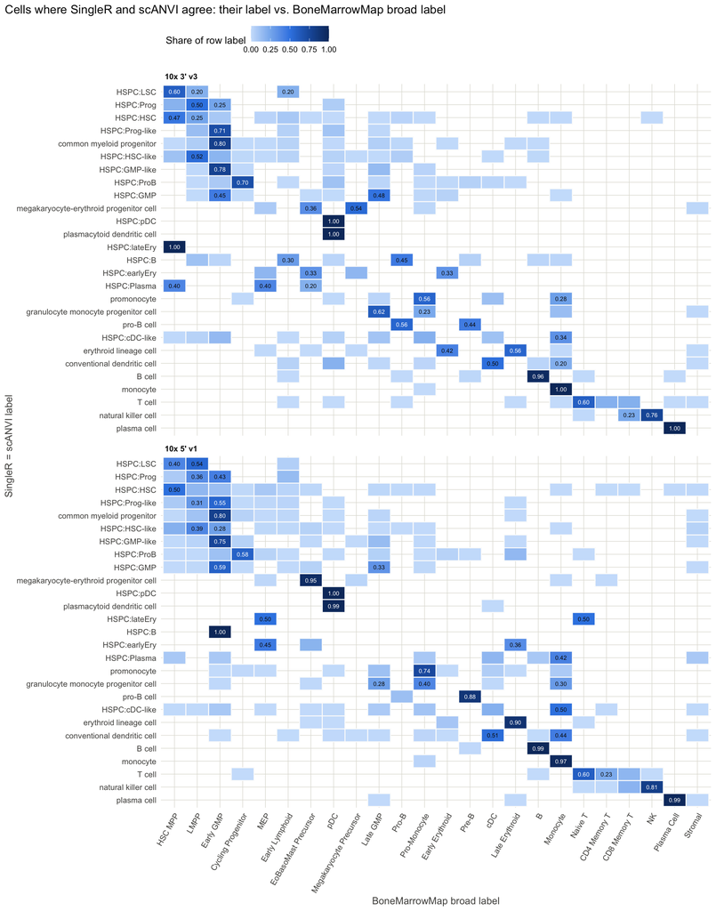

```r
consensus_vs_bmm <- cells |>
  filter(atlas_consensus) |>
  transmute(assay, row = singler_fine, col = bmm_label_broad)

plot_crosstab(
  consensus_vs_bmm,
  title = "Cells where SingleR and scANVI agree: their label vs. BoneMarrowMap broad label",
  row_title = "SingleR = scANVI label",
  col_title = "BoneMarrowMap broad label",
  row_levels = diagonal_row_order(consensus_vs_bmm, bmm_broad_levels),
  col_levels = bmm_broad_levels
)
```

Is BoneMarrowMap’s confidence related to whether the atlas-trained methods agree, and to their own confidence? Spearman correlations within each assay, over all cells.

```r
cells |>
  group_by(assay) |>
  summarize(
    error_vs_singler_delta = cor(bmm_mapping_error, singler_delta_next, method = "spearman"),
    error_vs_scanvi_prob = cor(bmm_mapping_error, scanvi_max_prob, method = "spearman"),
    knn_prob_vs_singler_delta = cor(bmm_label_prob, singler_delta_next, method = "spearman"),
    knn_prob_vs_scanvi_prob = cor(bmm_label_prob, scanvi_max_prob, method = "spearman")
  ) |>
  knitr::kable(digits = 3)
```

| assay | error_vs_singler_delta | error_vs_scanvi_prob | knn_prob_vs_singler_delta | knn_prob_vs_scanvi_prob |
| --- | --- | --- | --- | --- |
| 10x 3’ v3 | -0.198 | -0.424 | 0.297 | 0.299 |
| 10x 5’ v1 | -0.364 | -0.546 | 0.322 | 0.292 |

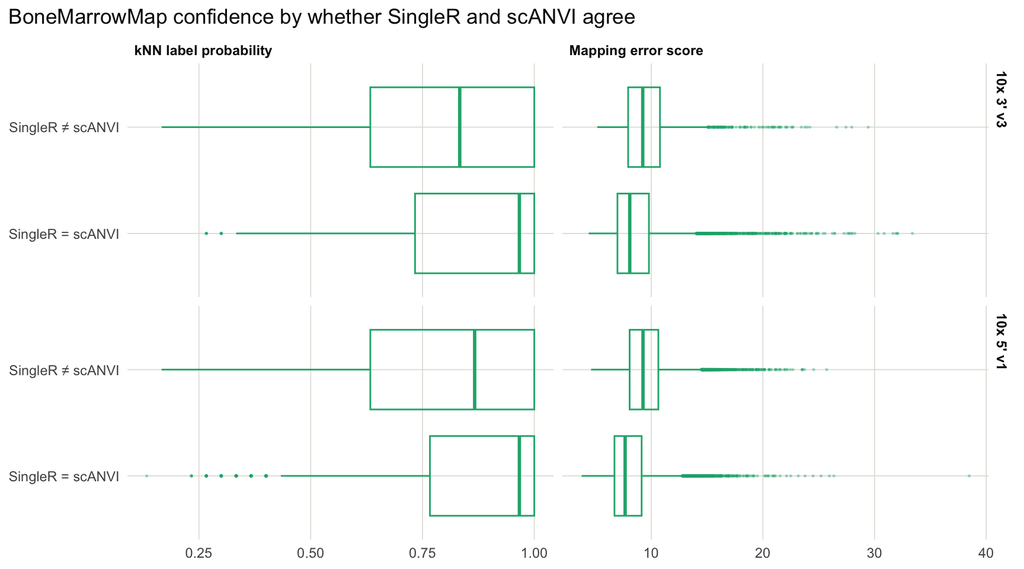

```r
cells |>
  mutate(atlas_consensus = if_else(atlas_consensus, "SingleR = scANVI", "SingleR ≠ scANVI")) |>
  tidyr::pivot_longer(c(bmm_mapping_error, bmm_label_prob), names_to = "measure") |>
  mutate(measure = recode(
    measure,
    bmm_mapping_error = "Mapping error score",
    bmm_label_prob = "kNN label probability"
  )) |>
  ggplot(aes(x = value, y = atlas_consensus)) +
  geom_boxplot(color = method_colors[["BoneMarrowMap"]], fill = NA, outlier.size = 0.3,
               outlier.alpha = 0.3) +
  facet_grid(assay ~ measure, scales = "free_x") +
  labs(x = NULL, y = NULL,
       title = "BoneMarrowMap confidence by whether SingleR and scANVI agree")
```

## Malignancy proxy

The atlas’s only per-cell malignancy signal is the `-like`/`LSC` HSPC sub-labels (see `reference.md`). Where do those cells land in BoneMarrowMap, compared with the other HSPC sub-labels? Rows are true HSPC sub-labels (true `label_broad` = `hematopoietic stem cell`).

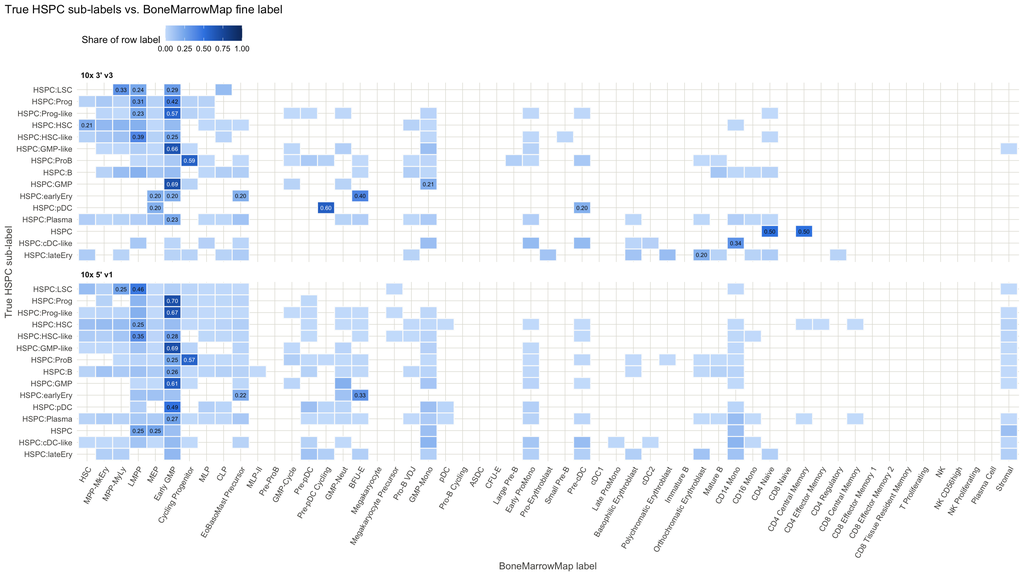

```r
hspc_vs_bmm <- cells |>
  filter(true_broad == "hematopoietic stem cell") |>
  transmute(assay, row = true_fine, col = bmm_label)

plot_crosstab(
  hspc_vs_bmm,
  title = "True HSPC sub-labels vs. BoneMarrowMap fine label",
  row_title = "True HSPC sub-label",
  col_title = "BoneMarrowMap label",
  row_levels = diagonal_row_order(hspc_vs_bmm, bmm_fine_levels),
  col_levels = bmm_fine_levels
)
```

Pseudotime of `-like`/`LSC` cells compared with the other HSPCs. HSPCs that BoneMarrowMap places outside the hierarchy (T, NK, plasma, stromal labels) have no pseudotime and are left out; the table shows how many.

```r
cells |>
  filter(true_broad == "hematopoietic stem cell") |>
  group_by(assay, group = if_else(true_mal, "-like/LSC", "other HSPC")) |>
  summarize(n_cells = n(), n_off_hierarchy = sum(bmm_off_hierarchy), .groups = "drop") |>
  knitr::kable()
```

| assay | group | n_cells | n_off_hierarchy |
| --- | --- | --- | --- |
| 10x 3’ v3 | -like/LSC | 373 | 3 |
| 10x 3’ v3 | other HSPC | 652 | 8 |
| 10x 5’ v1 | -like/LSC | 2505 | 27 |
| 10x 5’ v1 | other HSPC | 2556 | 44 |

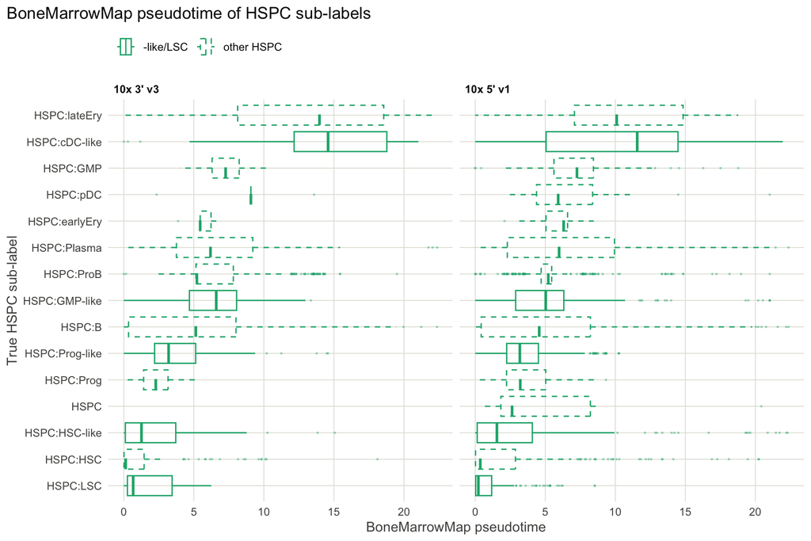

```r
cells |>
  filter(true_broad == "hematopoietic stem cell", !bmm_off_hierarchy) |>
  mutate(group = if_else(true_mal, "-like/LSC", "other HSPC")) |>
  ggplot(aes(x = bmm_pseudotime, y = reorder(true_fine, bmm_pseudotime, FUN = median),
             linetype = group)) +
  geom_boxplot(color = method_colors[["BoneMarrowMap"]], fill = NA, outlier.size = 0.3,
               outlier.alpha = 0.3) +
  facet_wrap(~assay) +
  scale_linetype_manual(values = c(`-like/LSC` = "solid", `other HSPC` = "dashed"), name = NULL) +
  labs(x = "BoneMarrowMap pseudotime", y = "True HSPC sub-label",
       title = "BoneMarrowMap pseudotime of HSPC sub-labels")
```

## Pseudotime by true label

A sanity check: does BoneMarrowMap’s pseudotime order the atlas labels sensibly (stem cells early, mature cells late)? Only cells with a defined pseudotime (hierarchy labels). True T, NK and plasma cells mostly drop out, which is expected, and labels with fewer than 20 such cells in an assay are left out.

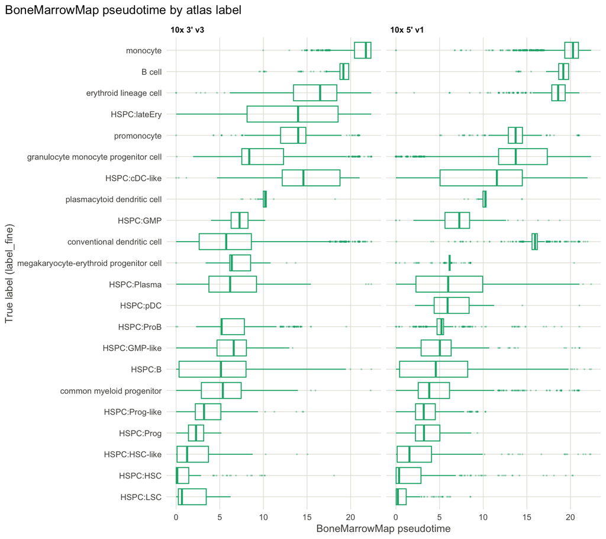

```r
cells |>
  filter(!bmm_off_hierarchy) |>
  add_count(assay, true_fine, name = "n_label") |>
  filter(n_label >= 20) |>
  ggplot(aes(x = bmm_pseudotime, y = reorder(true_fine, bmm_pseudotime, FUN = median))) +
  geom_boxplot(color = method_colors[["BoneMarrowMap"]], fill = NA, outlier.size = 0.3,
               outlier.alpha = 0.3) +
  facet_wrap(~assay) +
  labs(x = "BoneMarrowMap pseudotime", y = "True label (label_fine)",
       title = "BoneMarrowMap pseudotime by atlas label")
```

## BoneMarrowMap `Stromal` cells

AML marrow aspirates shouldn’t contain many stromal cells, so what are the cells BoneMarrowMap calls `Stromal`?

```r
stromal <- cells |> filter(bmm_label == "Stromal")

stromal |>
  group_by(assay) |>
  summarize(n_cells = n(), frac_pass_qc = mean(bmm_pass)) |>
  knitr::kable(digits = 3)
```

| assay | n_cells | frac_pass_qc |
| --- | --- | --- |
| 10x 3’ v3 | 27 | 0.667 |
| 10x 5’ v1 | 93 | 0.806 |

```r
stromal |>
  count(assay, true_fine, singler_fine, scanvi_fine, sort = TRUE) |>
  head(20) |>
  knitr::kable()
```

| assay | true_fine | singler_fine | scanvi_fine | n |
| --- | --- | --- | --- | --- |
| 10x 3’ v3 | erythroid lineage cell | erythroid lineage cell | erythroid lineage cell | 5 |
| 10x 5’ v1 | HSPC:HSC | HSPC:HSC-like | HSPC:HSC-like | 5 |
| 10x 5’ v1 | HSPC:HSC | HSPC:cDC-like | HSPC:HSC | 4 |
| 10x 3’ v3 | conventional dendritic cell | conventional dendritic cell | conventional dendritic cell | 3 |
| 10x 3’ v3 | granulocyte monocyte progenitor cell | HSPC:HSC | granulocyte monocyte progenitor cell | 3 |
| 10x 5’ v1 | HSPC:HSC | HSPC:HSC | HSPC:HSC-like | 3 |
| 10x 5’ v1 | HSPC:HSC | HSPC:HSC-like | HSPC:HSC | 3 |
| 10x 5’ v1 | HSPC:HSC-like | HSPC:cDC-like | HSPC:HSC-like | 3 |
| 10x 5’ v1 | HSPC:Prog-like | HSPC:cDC-like | HSPC:Prog-like | 3 |
| 10x 5’ v1 | granulocyte monocyte progenitor cell | HSPC:cDC-like | granulocyte monocyte progenitor cell | 3 |
| 10x 5’ v1 | granulocyte monocyte progenitor cell | conventional dendritic cell | HSPC:cDC-like | 3 |
| 10x 3’ v3 | conventional dendritic cell | HSPC:HSC | HSPC:GMP-like | 2 |
| 10x 5’ v1 | HSPC:GMP-like | HSPC:GMP-like | HSPC:GMP-like | 2 |
| 10x 5’ v1 | HSPC:GMP-like | HSPC:HSC-like | HSPC:HSC | 2 |
| 10x 5’ v1 | HSPC:HSC | HSPC:HSC | HSPC:HSC | 2 |
| 10x 5’ v1 | HSPC:HSC | HSPC:HSC | HSPC:Prog | 2 |
| 10x 5’ v1 | HSPC:HSC | HSPC:HSC-like | HSPC:LSC | 2 |
| 10x 5’ v1 | HSPC:HSC-like | HSPC:HSC-like | HSPC:HSC-like | 2 |
| 10x 5’ v1 | common myeloid progenitor | HSPC:HSC | HSPC:HSC | 2 |
| 10x 5’ v1 | granulocyte monocyte progenitor cell | conventional dendritic cell | conventional dendritic cell | 2 |